| title: “Projekt - Zbiór różnych parametrów słuchotek (uchowców) – ślimaków morskich” |
| --- |
| author: “Mateusz Korolow” |
| date: “25 styczeń, 2020” |

# Spis treści

1. Wstęp
2. Wykorzystane biblioteki
3. Wczytanie danych
4. Podstawowe statystyki
5. Uzupełnienie brakujących danych
6. Szczegółowa analiza wartości atrybutów
7. Korelacja pomiędzy atrybutami
8. Regresor
9. Analiza ważności atrybutów
10. Klasyfikator

## Wstęp

Poniższy raport ma na celu podjęcie analizy danych opisujących cechy anatomiczne słuchotek. Znaleziony zbiór (http://archive.ics.uci.edu/ml/datasets/Abalone) jest kompletny, dlatego na jego postawie wygenerowano nowy plik usuwając z niego część danych (~5%). W projekcie wykorzystano zmodyfikowany plik danch dostępny w projekcie na platformie GitHub.Brakujące wartości numeryczne zostały uzupełnione średnimi wartościami dla konkretnych atrybutów, natomiast brakujące informacje o płci uzupełniono wartością najczęściej występującą.

## Wykorzystane biblioteki

```r
library(knitr)
library(tibble)
library(tidyverse)
library(caret)
library(corrplot)
```

## Wczytanie danych

Wczytanie pliku *.csv z danymi i wyznaczenie typu danych

```r
initial <- read.table("abalone_missing.csv", nrows = 4177, sep = ';', comment.char = "", na.strings = '?', header = TRUE)
classes <- sapply(initial, class)
data <- read.table("abalone_missing.csv", sep = ';', comment.char = "", na.strings = '?', header = TRUE, colClasses = classes)
```

## Podstawowe statystyki

Wczytano 4177 wierszy, które opisują 9 cech.

```r
kable(summary(data))
```

|  | Sex | Length | Diameter | Height | Whole.weight | Shucked.weight | Viscera.weight | Shell.weight | Rings |
| --- | --- | --- | --- | --- | --- | --- | --- | --- | --- |
|  | F :1247 | Min. :0.0750 | Min. :0.0550 | Min. :0.0000 | Min. :0.0020 | Min. :0.0010 | Min. :0.0005 | Min. :0.0015 | Min. : 1.000 |
|  | I :1277 | 1st Qu.:0.4500 | 1st Qu.:0.3500 | 1st Qu.:0.1150 | 1st Qu.:0.4425 | 1st Qu.:0.1860 | 1st Qu.:0.0940 | 1st Qu.:0.1300 | 1st Qu.: 8.000 |
|  | M :1456 | Median :0.5450 | Median :0.4250 | Median :0.1400 | Median :0.7980 | Median :0.3350 | Median :0.1715 | Median :0.2343 | Median : 9.000 |
|  | NA’s: 197 | Mean :0.5242 | Mean :0.4073 | Mean :0.1393 | Mean :0.8294 | Mean :0.3587 | Mean :0.1807 | Mean :0.2390 | Mean : 9.927 |
|  | NA | 3rd Qu.:0.6150 | 3rd Qu.:0.4800 | 3rd Qu.:0.1650 | 3rd Qu.:1.1530 | 3rd Qu.:0.5010 | 3rd Qu.:0.2530 | 3rd Qu.:0.3296 | 3rd Qu.:11.000 |
|  | NA | Max. :0.8150 | Max. :0.6500 | Max. :1.1300 | Max. :2.8255 | Max. :1.3510 | Max. :0.7600 | Max. :1.0050 | Max. :29.000 |
|  | NA | NA’s :220 | NA’s :207 | NA’s :190 | NA’s :192 | NA’s :196 | NA’s :185 | NA’s :205 | NA’s :199 |

## Uzupełnienie brakujących danych

Utworzenie funkcji zajmującej się zastępowaniem wartości NA we wskazanej kolumnie wartością najczęściej w niej występującą. Wywołanie zdefiniowanej metody dla kolumny pierwszej (płeć słuchotki).

```r
get_most_common <- function(x){
  return(names(sort(table(x), decreasing = T, na.last = T)[1]))
}
data[is.na(data[,1]), 1] <- get_most_common(data$Sex)
```

Zastąpienie wartości NA (iteracyjnie) dla kolejnych atrybutów ich wartościami uśrednionymi.

```r
for(i in 2:ncol(data)){
  data[is.na(data[,i]), i] <- mean(data[,i], na.rm = TRUE)
}
```

## Szczegółowa analiza wartości atrybutów

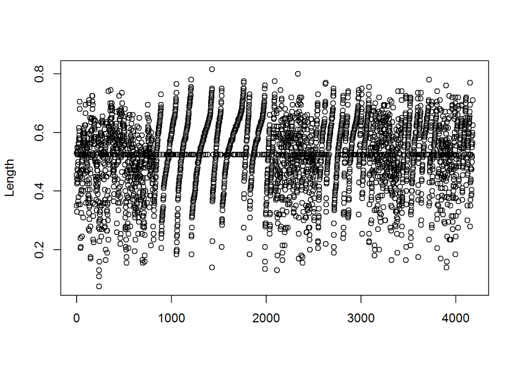

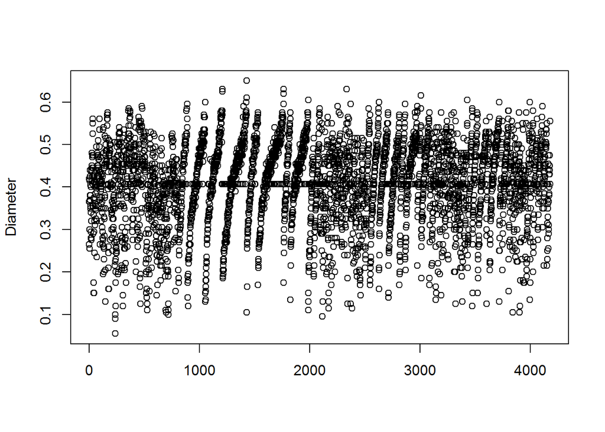

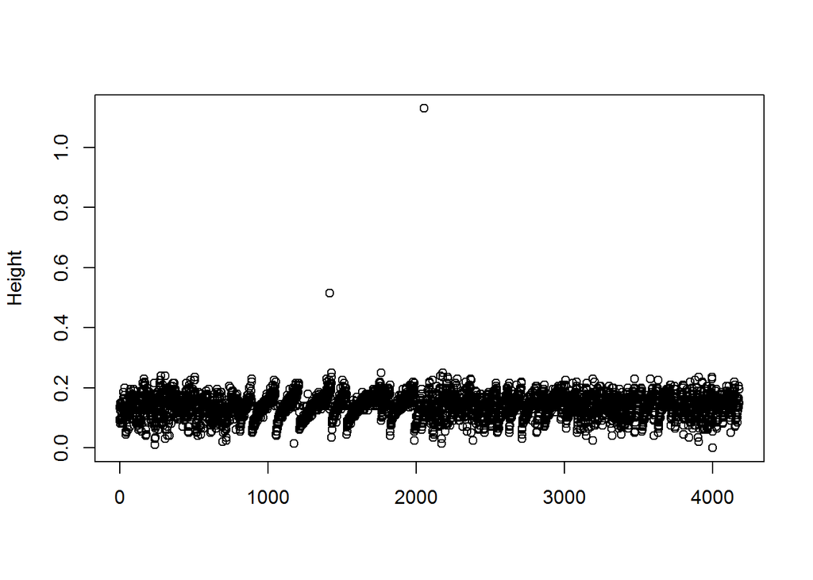

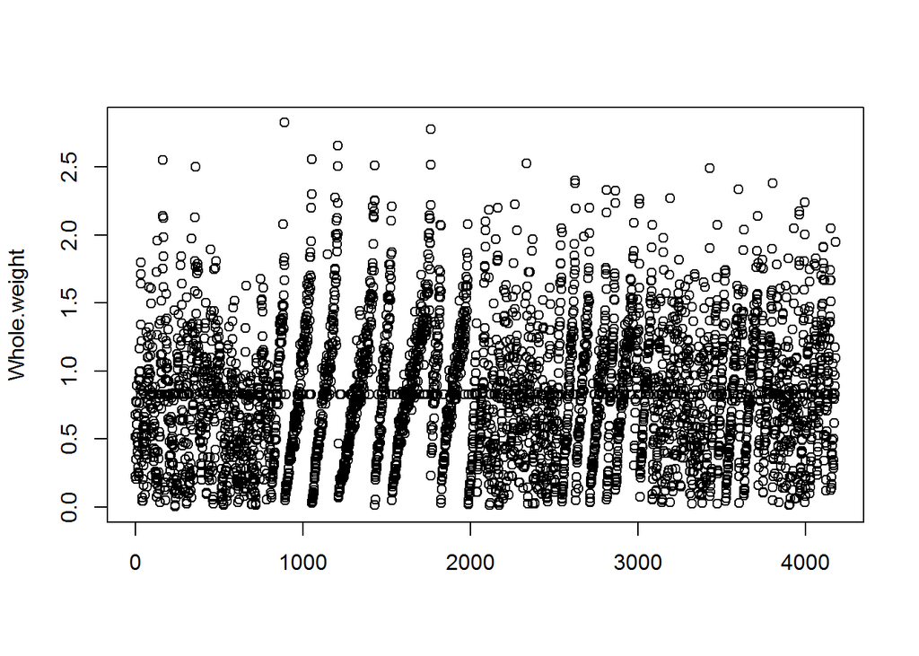

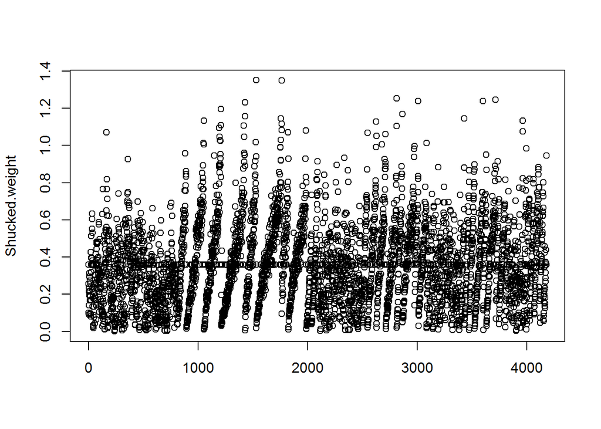

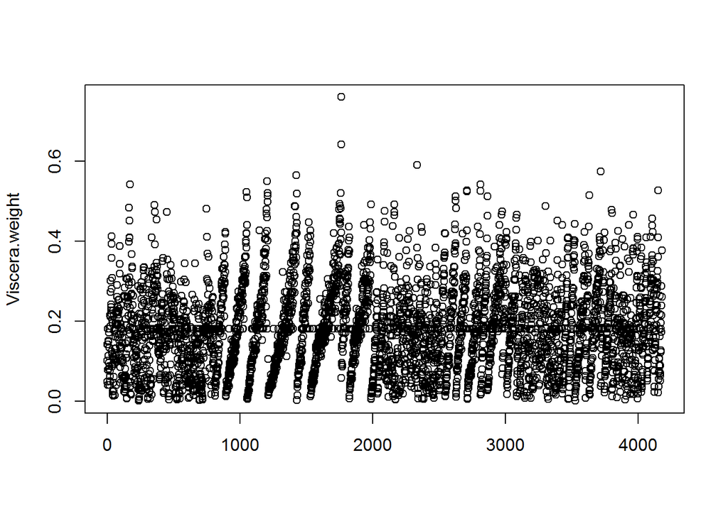

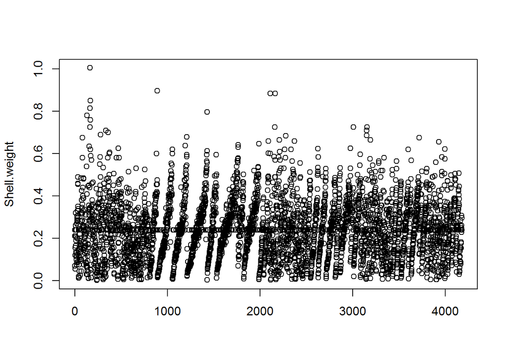

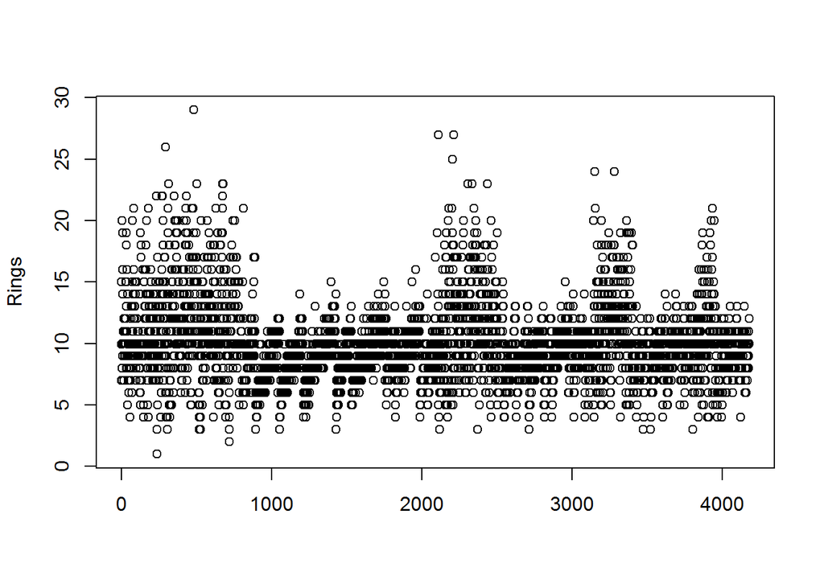

```r
for(i in 2:ncol(data)){
  plot(c(1:nrow(data)), c(data[,i]) ,type = 'p', xlab = '', ylab = names(data[i]))
}
```

## Korelacja pomiędzy atrybutami

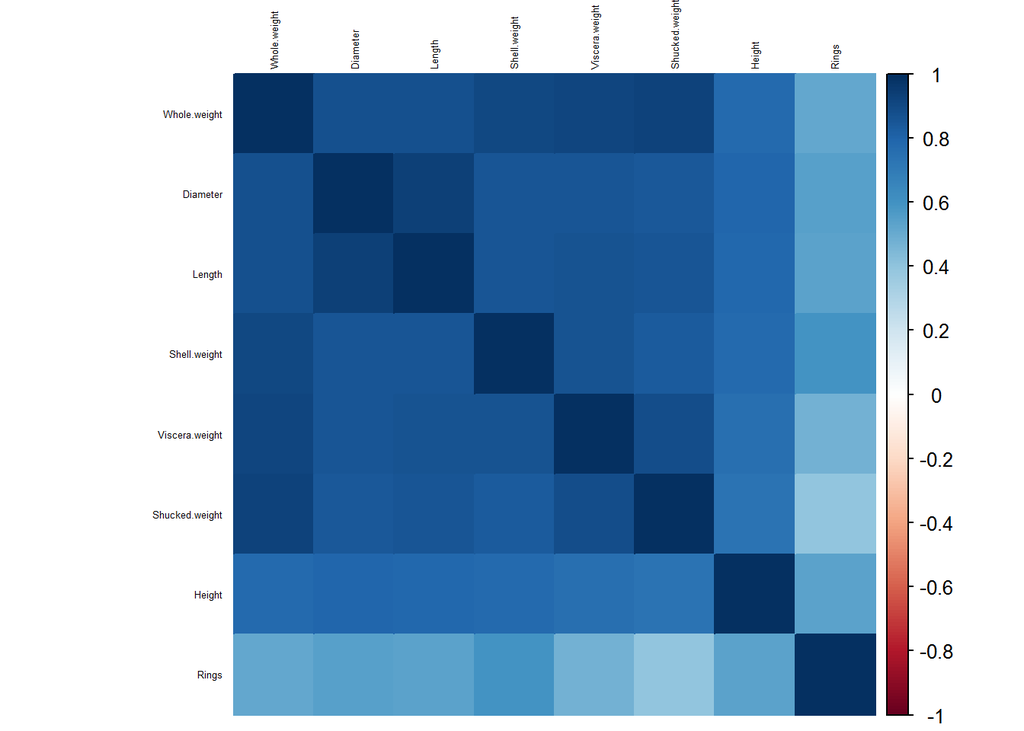

```r
correlation_data  <- cor(data[,2:9], use = "pairwise.complete.obs")
corrplot(correlation_data, method = "color", tl.cex = 0.4, order = "FPC", tl.col="black")
```

Możemy zauważyć mocną korelację pomiędzy długością słuchotki, a wagą jej skorupy. Im dłuższa jest, tym jej skorupa ma większą wagę.

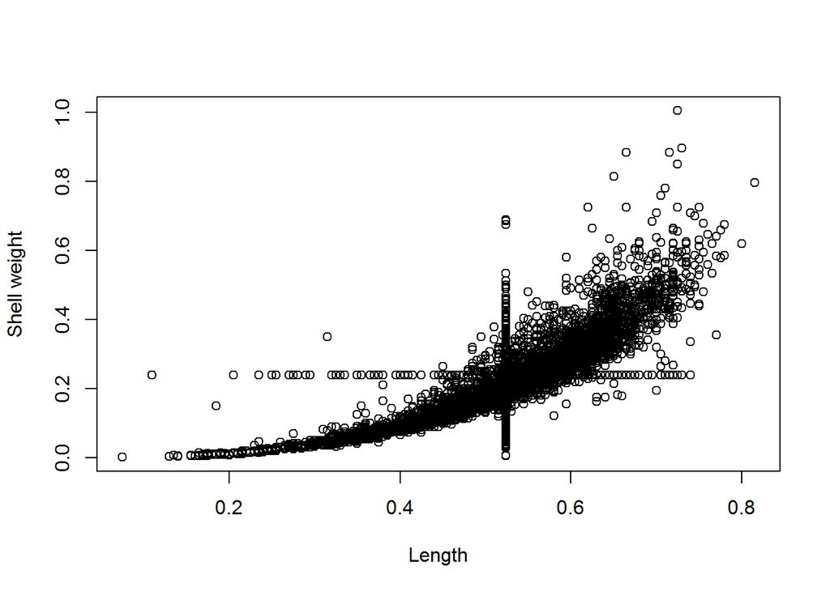

```r
plot(data$Length, data$Shell.weight ,type = 'p', xlab = 'Length', ylab = 'Shell weight')
```

Zauważalna jest również zależność pomiędzy wagą muszli, a ilością pierścieni słuchotki. Prawdopodobnie wynika to z wmiarów skorupy (cięższa muszla jest większa, zatem jest w stanie pomieścić większą ilość pierścieni). Widać również, że liczba pierścieni słuchotki jest ograniczona, ponieważ tendencje wzrostowe wykresu zaczynają maleć wraz z wagą muszli.

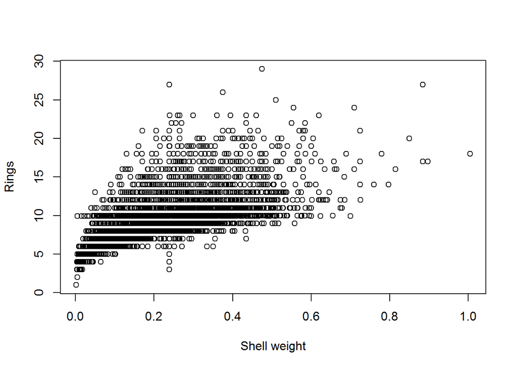

```r
plot(data$Shell.weight, data$Rings ,type = 'p', xlab = 'Shell weight', ylab = 'Rings')
```

## Regresor

```r
rdf <- data %>% select(1, 2, 4, 5, 8, 9)
forTraining <- createDataPartition(y = rdf$Length, p = .75, list = FALSE)

set.seed(123)

trainingSet <- rdf[forTraining, ]
testingSet <- rdf[-forTraining, ]

ctrl <- trainControl(method = "repeatedcv", number = 2,repeats = 3)
fitLm <- train(Length ~ ., data = trainingSet, method = "lm", metric = "RMSE", trControl = ctrl)

lmPredict<-predict(fitLm, newdata=testingSet)
postResample(lmPredict,testingSet$Length)
```

```
##       RMSE   Rsquared        MAE
## 0.05178246 0.80731315 0.03774283
```

## Analiza ważności atrybutów

```r
fitLm %>% summary()
```

```
##
## Call:
## lm(formula = .outcome ~ ., data = dat)
##
## Residuals:
##      Min       1Q   Median       3Q      Max
## -0.51929 -0.02188  0.00685  0.03060  0.20671
##
## Coefficients:
##                Estimate Std. Error t value Pr(>|t|)
## (Intercept)   0.3047928  0.0049484  61.594  < 2e-16 ***
## SexI         -0.0137616  0.0027898  -4.933 8.52e-07 ***
## SexM         -0.0043965  0.0022318  -1.970   0.0489 *
## Height        0.4983607  0.0353567  14.095  < 2e-16 ***
## Whole.weight  0.1291310  0.0048227  26.776  < 2e-16 ***
## Shell.weight  0.1668935  0.0176579   9.451  < 2e-16 ***
## Rings         0.0009205  0.0003806   2.419   0.0156 *
## ---
## Signif. codes:  0 '***' 0.001 '**' 0.01 '*' 0.05 '.' 0.1 ' ' 1
##
## Residual standard error: 0.05135 on 3128 degrees of freedom
## Multiple R-squared:  0.8071, Adjusted R-squared:  0.8068
## F-statistic:  2182 on 6 and 3128 DF,  p-value: < 2.2e-16
```

## Klasyfikator

Próba utworzenia modelu klasyfikującego płeć słuchotek. Wykorzystanie algorytmu klasyfikacji random forest i walidacji krzyżowej uzyskując ~ 52% miary accuracy.

```r
cdf <- data %>% select(1, 2, 4, 5, 8, 9)
forTrainingClassifier <- createDataPartition(y = cdf$Sex, p = .75, list = FALSE)

set.seed(123)

trainingClassifierSet <- rdf[forTrainingClassifier, ]
testingClassifierSet <- rdf[-forTrainingClassifier, ]

ctrl <- trainControl(method = "repeatedcv", number = 2,repeats = 3)

clsf <- train(Sex ~ ., trainingClassifierSet, method = 'rf', TuneLength = 5, trainControl = ctrl)

print(clsf$results)
```

```
##   mtry  Accuracy     Kappa  AccuracySD    KappaSD
## 1    2 0.5170289 0.2665256 0.011699276 0.01753671
## 2    3 0.5154077 0.2641756 0.009973623 0.01460533
## 3    5 0.5108167 0.2574452 0.010511346 0.01547042
```

Rezultaty

```r
predictedData <- predict(clsf, testingClassifierSet)
table(predictedData, testingClassifierSet$Sex)
```

```
##
## predictedData   F   I   M
##             F  97  31 110
##             I  39 231  73
##             M 175  57 230
```